# Exercise3

Fortgeschrittene Statistische Software für NF - SS 2024

BaoruZhang-12300416

2024-06-01

## Exercise 1: Initializing git (4 Points)

For this whole exercise sheet we will be tracking all our changes to it in git.

1. Start by initializing a new R project with git support, called `2024-exeRcise-sheet-3`. If you forgot how to do this, you can follow this [guide](https://malikaihle.github.io/Introduction-RStudio-Git-GitHub/rstudio_project.html).
2. Commit the files generated by Rstudio.

   commit 4b55dc3573aa81fb729ea892249ca04e29064cec Author: BaoruZhang gongzhong@163.com Date: Thu May 30 21:42:16 2024 +0800

   commit 77358d0f73003c0bb3196c1ca9dd89ac0e9e9d8c Author: BaoruZhang gongzhong@163.com Date: Thu May 30 21:31:46 2024 +0800
3. For all of the following tasks in this exercise sheet we ask you to always commit your changes after finishing each subtask e.g. create a commit after task *1d*, *1e* etc.
4. Name 2 strengths and 2 weaknesses of git. (Don’t forget to create a commit after this answer, see *1c*)

   Two strengths of git:
   1. Distributed Version Control: Git allows each developer to have their own local copy of the entire project repository, enabling them to work offline and independently. This decentralization makes collaboration easier and reduces the risk of data loss.
   2. Branching and Merging: Git provides powerful branching and merging capabilities, allowing developers to work on isolated features or fixes in separate branches and later merge them back into the main codebase. This enables parallel development and facilitates code review and release management.

   Two weaknesses of git:
   1. Learning Curve: Git has a steep learning curve, especially for beginners. Its extensive feature set and command-line interface can be intimidating for new users, requiring time and effort to become proficient.
   2. Conflicts and Merge Issues: While branching and merging are powerful features, they can sometimes lead to conflicts, especially in large and complex projects with multiple contributors. Resolving conflicts manually can be time-consuming and error-prone, requiring careful attention to ensure the integrity of the codebase.
5. Knit this exercise sheet. Some new files will automatically be generated when knitting the sheet e.g. the HTML page. Ignore these files, as we only want to track the source files themselves.

## Exercise 2: Putting your Repository on GitHub (3.5 Points)

For this task you will upload your solution to GitHub.

1. Create a new repository on GitHub in your account named `exeRcise-sheet-3`. Make sure you create a **public repository** so we are able to see it for grading. Add the link to the repository below:

   https://github.com/ww4869/exeRcise-sheet-3
2. Push your code to this new repository by copying and executing the snippet on github listed under or push an existing repository from the command line
3. Regularly push your latest changes to GitHub again and especially do so when you are finished with this sheet.

## Exercise 3: Baby-Names in Munich (3.5 Points)

Download the latest open datasets on given names (“Vornamen”) from the open data repository of the city of Munich for the years `2023` and `2022`.

Link: https://opendata.muenchen.de/dataset/vornamen-von-neugeborenen

1. Download the data for both years and track it in git. For small datasets like these adding them to git is not a problem.
2. Load the data for both years into R. Check the type of the count variable (“Anzahl”) and look into the data to determine why it is not numeric? Fix the problem in an appropriate manner, it is OK if some of the counts are inaccurate because of this. Explain your solution and the repercussions.

```r
baby_name_2022<-read.csv('open_data_portal_2022.csv')
baby_name_2023<-read.csv('vornamen-muenchen-2023.csv')

print(typeof(baby_name_2022$Anzahl))
```

```
## [1] "character"
```

```r
print(typeof(baby_name_2023$Anzahl))
```

```
## [1] "character"
```

```r
baby_name_2022$Anzahl <- as.numeric(gsub("4 oder weniger", "4", baby_name_2022$Anzahl))

baby_name_2023$Anzahl <- as.numeric(gsub("4 oder weniger", "4", baby_name_2023$Anzahl))

print(typeof(baby_name_2022$Anzahl))
```

```
## [1] "double"
```

```r
print(typeof(baby_name_2023$Anzahl))
```

```
## [1] "double"
```

Analyzing the dataset, it can be seen that there is “4 oder weniger” in the Anzahl variable, which causes the data type of this column to be characters, and in order to facilitate subsequent calculation, the value of 4 is taken for this case

3. Calculate the total number of babies born in Munich in 2022 and 2023. Which year had the bigger baby-boom?

```r
cat('the total number of babies born in Munich in 2022 is',sum(baby_name_2022$Anzahl),
    '\nthe total number of babies born in Munich in 2023 is',sum(baby_name_2023$Anzahl))
```

```
## the total number of babies born in Munich in 2022 is 25199
## the total number of babies born in Munich in 2023 is 24229
```

From the results, it can be seen that 2022 had the bigger baby-boom

4. Add a new column `year` to both datasets which holds the correct year for each.

```r
baby_name_2022$year <- 2022
baby_name_2023$year <- 2023
```

5. Combine both datasets into one using `bind_rows()`.

```r
combined_data <- dplyr::bind_rows(baby_name_2022, baby_name_2023)
```

6. Combine the counts for same names to determine the most popular names across both years. Print out the top 10 names in a nicely formatted table for both years. Include a table caption.

```r
options (warn = -1)
suppressPackageStartupMessages(library(dplyr))
popular_names <- combined_data %>%
  group_by(Vorname, Geschlecht) %>%
  summarise(Total = sum(Anzahl, na.rm = TRUE)) %>%
  arrange(desc(Total))
top_names <- head(popular_names, 10)

knitr::kable(top_names, caption = "Top 10 Most Popular Names in Munich for 2022 and 2023")
```

Top 10 Most Popular Names in Munich for 2022 and 2023

| Vorname | Geschlecht | Total |
| --- | --- | --- |
| Maximilian | m | 209 |
| Emilia | w | 192 |
| Leon | m | 188 |
| Anton | m | 181 |
| Emma | w | 172 |
| Felix | m | 166 |
| Mia | w | 163 |
| Paul | m | 161 |
| Noah | m | 159 |
| Jonas | m | 158 |

## Exercise 4: Open Analysis (4 points)

This exercise is a bit more open-ended. You can choose any dataset from [Our World in Data](https://ourworldindata.org/) and analyze it, while determining the research question yourself.

1. Go to https://github.com/owid/owid-datasets/tree/master/datasets and choose a dataset that interests you. You can have a look at https://ourworldindata.org/ to gather some inspiration.
2. Download the dataset and track it in git.
3. Put the name / title of the dataset and a link to it below.
- Dataset Name: Human Height - NCD RisC (2017)
- Link:https://github.com/owid/owid-datasets/tree/master/datasets/Human%20Height%20-%20NCD%20RisC%20(2017)
4. Come up with a (research) question you want to answer with the data and briefly explain why you believe this is an interesting question within one sentence. It should be a question that can be answered with the dataset and using R.
5. Use R to answer your chosen question.
6. Create a meaningful plot / figure with the dataset. Make sure to provide a figure caption (via the chunk options / Rmarkdown) and correctly label the figure.

question-1: Calculate the average height of men and women in each country, and export the top 10 countries with average male height and the top 10 countries with average female height, and see if there are countries with high average height for both men and women

```r
height_data<-read.csv('Human_Height.csv')

male_mean_height<- height_data %>%
    group_by(Entity) %>%
    summarise(mean_male_height = mean(Mean_male_height)) %>%
    arrange(desc(mean_male_height))

female_mean_height<-height_data %>%
    group_by(Entity) %>%
    summarise(mean_female_height = mean(Mean_female_height)) %>%
    arrange(desc(mean_female_height))

top10_male_height_country<-head(male_mean_height,10)
top10_female_height_country<-head(female_mean_height,10)

knitr::kable(top10_male_height_country, caption = "Top 10 Countries by Male Average Height")
```

Top 10 Countries by Male Average Height

| Entity | mean_male_height |
| --- | --- |
| Iceland | 178.1461 |
| Netherlands | 177.7963 |
| Sweden | 177.1223 |
| Norway | 177.0508 |
| Estonia | 176.7181 |
| Denmark | 176.6585 |
| Bosnia and Herzegovina | 176.0083 |
| United States | 175.6469 |
| Latvia | 175.3445 |
| Finland | 175.1353 |

```r
knitr::kable(top10_female_height_country, caption = "Top 10 Countries by Female Average Height")
```

Top 10 Countries by Female Average Height

| Entity | mean_female_height |
| --- | --- |
| Iceland | 165.1021 |
| Netherlands | 164.5489 |
| Sweden | 164.3252 |
| Denmark | 164.1915 |
| Norway | 164.1452 |
| Estonia | 163.7082 |
| Tonga | 163.6050 |
| Latvia | 163.5323 |
| Bosnia and Herzegovina | 163.1363 |
| Slovakia | 162.8631 |

From the analysis results, it can be seen that the top 3 countries with the average height of men are Iceland, Netherlands, and Sweden, which are exactly the same as the top 3 countries with the average height of women! This indicates that the inhabitants of these countries are generally taller

question-2:Use a histogram to show the average height distribution of men and women in the top 10 countries

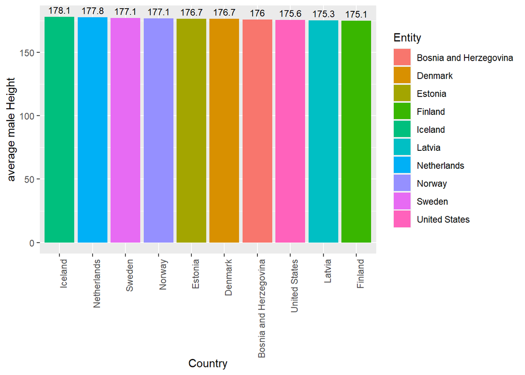

Top 10 Countries by Male Average Height

```r
suppressPackageStartupMessages(library(ggplot2))

ggplot(top10_male_height_country,
       aes(x = reorder(Entity,-mean_male_height), y =mean_male_height,fill=Entity))+
       geom_bar(stat="identity") +
      labs(x = "Country", y = "average male Height") +
       geom_text(aes(label = round(mean_male_height,1)), vjust = -0.5, size = 3, color = "black") +
       theme(axis.text.x = element_text(angle = 90, hjust = 1))
```

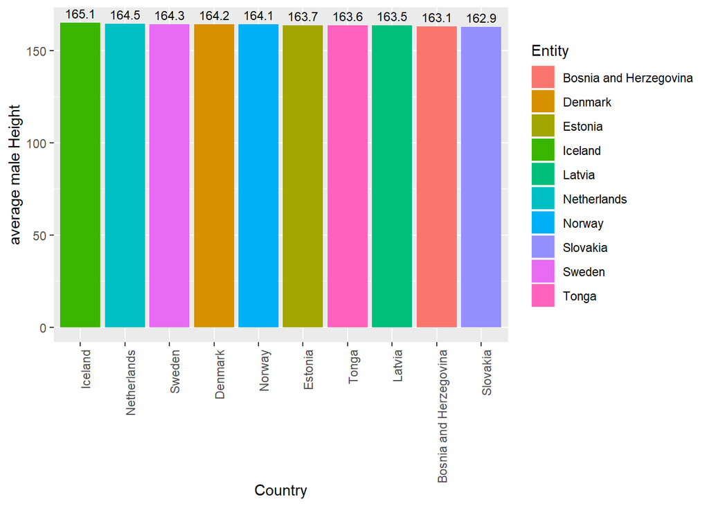

Top 10 Countries by Female Average Height

```r
suppressPackageStartupMessages(library(ggplot2))

ggplot(top10_female_height_country,
       aes(x = reorder(Entity,-mean_female_height), y = mean_female_height,fill=Entity))+
      geom_bar(stat="identity") +
      labs(x = "Country", y = "average male Height") +
      geom_text(aes(label = round(mean_female_height,1)), vjust = -0.5, size = 3, color = "black") +
      theme(axis.text.x = element_text(angle = 90, hjust = 1))
```